# Bayesian Forecasting of Small Inventory data

#### Jithakrishna Prakash | jprakashoff@gmail.com | linkedin.com/in/jithakrishna-prakash/

This project started as a personal exploration of the question “can I make forecasts with no predictor variables and based on modeling just the underlying stochastic process?”. I wanted to forecast demand for a small inventory data that I kept track of in my QC role. In this inventory data, there were no covariates available other than the date of inventory. In this project, I have used **Poisson-Gamma Mix Model** to attempt to model the stochastic process underlying the inventory data. I have used mock inventory data that mimics the actual data I encountered in my QC role. I have also masked sensitive information such as material names and expiry dates.

The potential benefits of this analysis were:

1. Optimization of restock frequency
2. Reduction of effort to perform frequent restocks
3. Optimum stock level that maximizes inventory level as well as minimize expected waste

# Stochastic Process

Bayesian analysis involves representing a stochastic process (random process) using known probability distributions called likelihood functions. Typically, these likelihood functions will need parameter values to work. We usually start with a range of values/a probability distribution for these parameter(s), called priors. Then we will obtain a new distribution called the posterior probability distribution by combining the likelihood and the prior using the Bayes Theorem. The posterior probability distribution will then be representative of the possible values of the random variable ranked by plausibility.

In this case, the nature of my inventory data is **Count Data**. Count data is fundamentally modeled using the **Poisson Distribution** as the likelihood function:

PMF: P(x; lambda) ~ lambda^x * exp(-lambda) / factorial(x)

where x is the count for one time period, lambda is the rate for one time period. In this problem, lambda is the daily usage which is assumed to be constant for a given week and the counts produced are weekly.

However, the underlying usage changes every week. So, lambda is assumed to follow the **Gamma Distribution**:

PDF: p(x; a, b) ~ b^a * x^(a-1) * exp(-lambda * x) / gamma(a)

where a is the size parameter and b is the rate parameter.

Here, the Gamma Distribution is the **prior** we assume for the lambda parameter of the Poisson likelihood.

Applying Bayes Theorem over Poisson Likelihood and Gamma Prior will result in a **closed-form expression** for the **Posterior Probability Distribution**, which is the **Negative Binomial Distribution** PMF: NegBinom(x; a, b/(1 + b)).

This is the posterior probability distribution for one occurrence in the time scale of lambda, which is **one day**. We assume that for k days, parameters a and b of the gamma prior do not change. Following this, to forecast consumption over a horizon of k days, we exploit a key property of Poisson processes: **counts scale linearly with exposure time**. If daily usage follows a Poisson process with rate lambda, then the total count over k days follows a Poisson distribution with mean lambda * k. However, the variability of lambda is already captured by the gamma prior.

This allows the posterior distribution to be extended to k days by NegBinom(x; a, b/(k + b)). We use this posterior distribution to model consumption for k days.

Since there is a closed-form expression for the posterior probability distribution, the Gamma distribution is called the **Conjugate Prior** of the Poisson Distribution.

Due to the posterior having a closed-form expression, the posterior update reduces into **simple parameter update rules** - parameter a: a_prior + sum(consumption), parameter b: b_prior + sum(days)

The Negative Binomial distribution exhibits properties such as right-tailed distribution, overdispersion in the random variable (variance is greater than the mean), and the variance and mean have a quadratic relationship.

The next section is the exploratory data analysis to assess the suitability of the Poisson-Gamma Mix Model for this dataset.

# Libraries

```r
library(readxl)
library(dplyr)
library(ggplot2)
library(lubridate)
library(stats)
library(patchwork)
library(geomtextpath)

set.seed(42)
```

# Data Loading and Feature Engineering

The raw data contains mock weekly stock counts that mimic the inventory data I encountered in a real world QC environment. The materials are high cost and have expiry windows of a few months.

```r
import_data <- readxl::read_excel("./UnitsUsed.xlsx", sheet=1)

import_data$Material <- as.factor(import_data$Material)
import_data$Date <- as.Date(import_data$Date, format="%m/%d/%Y")

import_data <- import_data%>%
  rename(date = Date)%>%
  rename(material = Material)%>%
  rename(n = `Days Since Last Inventory`)%>%
  rename(y = `Units Used in Week`)%>%
  rename(stock = Stock)%>%
  rename(rolling_y_in_cycle = `Total Used since last restock`)%>%
  rename(rolling_n_in_cycle = `Days since last restock`)%>%
  rename(total_y_prev_cycle = `Previous Cycle Total Use`)%>%
  rename(total_n_prev_cycle = `Previous Cycle Total Days`)
```

```r
head(import_data)
```

```
## # A tibble: 6 × 11
##   material  date       stock     y     n Restock Excess rolling_y_in_cycle
##   <fct>     <date>     <dbl> <dbl> <dbl> <lgl>    <dbl>              <dbl>
## 1 Material1 2024-05-01    29     0     7 TRUE         0                  0
## 2 Material1 2024-05-07    75    11     6 TRUE         0                 11
## 3 Material1 2024-05-14    50    25     7 FALSE        0                 36
## 4 Material1 2024-05-21    36    14     7 FALSE        0                 50
## 5 Material1 2024-05-25   113     0     4 TRUE         0                  0
## 6 Material1 2024-06-04   111     2    10 FALSE        0                  2
## # ℹ 3 more variables: rolling_n_in_cycle <dbl>, total_y_prev_cycle <dbl>,
## #   total_n_prev_cycle <dbl>
```

The raw data originally contained only the Material Name, Weekly Stock Count, and Expiration Date (not shown). I have hidden expiration dates to respect data privacy.

However, to make any forecast, the units used in week is required. For this, I wrote an **external Excel VBA script** that calculates the weekly units used **y** for all materials using combinations of checks such as: 1. Was restock performed in given week? 2. Is there expiry information available for the material in given week and previous week? 3. Did any units expire in previous week?

From this, all the other metrics in the data were calculated.

# Exploratory Data Analysis

## Data Visualization

```r
hist <- c(); cycle_lengths <- c()

for(m in unique(import_data$material)) {

  hist <- c(hist,
            ggplot(data=import_data%>%filter(material == m), aes(x=y)) +
            geom_histogram(aes(y=after_stat(density)), bins=20, fill="grey", color = "black") +
            geom_density(alpha=0.2, fill="red") +
            xlab("Units used per week") +
            labs(title=paste0(m, ": Units used per week")) +
            theme_minimal())

  cycle_lengths <- c(cycle_lengths,
                     ggplot(data=import_data%>%filter(material == m),
                          aes(x=total_n_prev_cycle, y=total_y_prev_cycle)) +
                          geom_point() +
                          geom_smooth(method="lm") +
                          xlab("Days in cycle") +
                          ylab("Total Units used in cycle") +
                          labs(title = paste0(m, ": Total used per stock cycle")) +
                          theme_minimal())

}
```

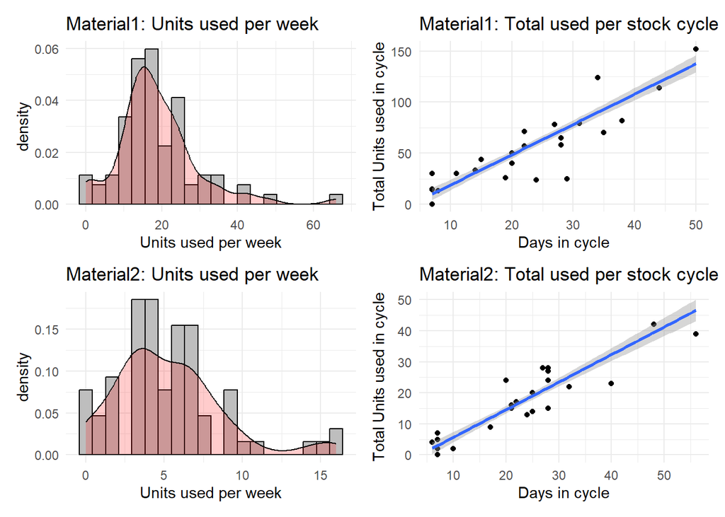

```r
patchwork::wrap_plots(hist[[1]], cycle_lengths[[1]], hist[[2]], cycle_lengths[[2]], ncol=2, nrow=2)
```

## Mean-Variance analysis of rolling windows

For any forecasting approach, we usually use rolling windows of the data to train the model. I wanted to assess the drift of mean and the variance of different rolling windows across the data.

```r
analyze_variance_mean <- function(data, window=8) {

  y <- data$y
  rolling_stats <- data.frame()

  for (i in window:length(y)) {
    train_data <- y[(i - window + 1):i]
    rolling_stats <- rbind(rolling_stats, data.frame(
      time_point = i,
      rolling_mean=mean(train_data),
      rolling_var=var(train_data),
      rolling_ratio=var(train_data)/mean(train_data)
    ))
  }

  par(mfrow=c(1,2))

  plot(rolling_stats$rolling_mean, rolling_stats$rolling_var,
       main="Variance-Mean relationship",
       xlab="Rolling Mean", ylab="Rolling Variance")

  if (nrow(rolling_stats) > 3) {
    lm_fit <- lm(rolling_var ~ rolling_mean, data=rolling_stats)
    abline(lm_fit, col="red")
    quad_fit <- lm(rolling_var ~ rolling_mean + I(rolling_mean^2), data=rolling_stats)
    print(summary(quad_fit))
    pred_vals <- predict(quad_fit, newdata=data.frame(rolling_mean = sort(rolling_stats$rolling_mean)))
    lines(pred_vals ~ sort(rolling_stats$rolling_mean))
  }


  plot(rolling_stats$time_point, rolling_stats$rolling_ratio,
       main="Var/Mean Ratio over Time (Weeks)",
       xlab="Week", ylab="Ratio")

  title(data$material[[1]], side = 3, line=-1, outer = TRUE)

  par(mfrow=c(1,1))

  mean_rolling_ratio <- mean(rolling_stats$rolling_ratio, na.rm=TRUE)
  sd_rolling_ratio <- sd(rolling_stats$rolling_ratio, na.rm=TRUE)
  ratio_cv <- sd_rolling_ratio / mean_rolling_ratio

  cat("ratio_cv: ", ratio_cv, "\n")

  return(rolling_stats)

}
```

```r
for(m in unique(import_data$material)) {

  analyze_variance_mean(data=import_data%>%filter(material == m))

}
```

```
##
## Call:
## lm(formula = rolling_var ~ rolling_mean + I(rolling_mean^2),
##     data = rolling_stats)
##
## Residuals:
##    Min     1Q Median     3Q    Max
## -90.15 -38.22 -25.40  20.76 162.79
##
## Coefficients:
##                   Estimate Std. Error t value Pr(>|t|)
## (Intercept)       176.9971    93.3982   1.895 0.062397 .
## rolling_mean      -19.0207     8.6722  -2.193 0.031760 *
## I(rolling_mean^2)   0.6972     0.1866   3.737 0.000387 ***
## ---
## Signif. codes:  0 '***' 0.001 '**' 0.01 '*' 0.05 '.' 0.1 ' ' 1
##
## Residual standard error: 61.48 on 67 degrees of freedom
## Multiple R-squared:  0.642,  Adjusted R-squared:  0.6313
## F-statistic: 60.07 on 2 and 67 DF,  p-value: 1.137e-15
```

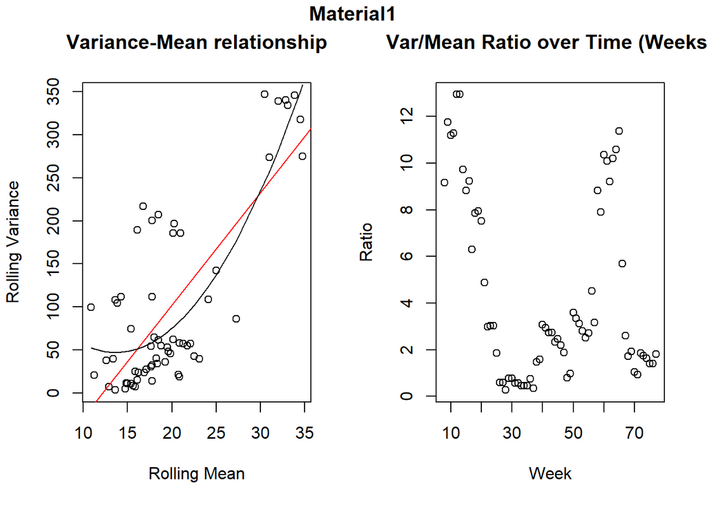

```
## ratio_cv:  0.8948743
```

```
##
## Call:
## lm(formula = rolling_var ~ rolling_mean + I(rolling_mean^2),
##     data = rolling_stats)
##
## Residuals:
##      Min       1Q   Median       3Q      Max
## -10.1454  -2.5738  -0.3656   2.5463  13.8005
##
## Coefficients:
##                   Estimate Std. Error t value Pr(>|t|)
## (Intercept)         2.8286    12.0346   0.235   0.8149
## rolling_mean       -1.9392     4.2102  -0.461   0.6466
## I(rolling_mean^2)   0.6246     0.3520   1.774   0.0806 .
## ---
## Signif. codes:  0 '***' 0.001 '**' 0.01 '*' 0.05 '.' 0.1 ' ' 1
##
## Residual standard error: 5.045 on 67 degrees of freedom
## Multiple R-squared:  0.6839, Adjusted R-squared:  0.6744
## F-statistic: 72.47 on 2 and 67 DF,  p-value: < 2.2e-16
```

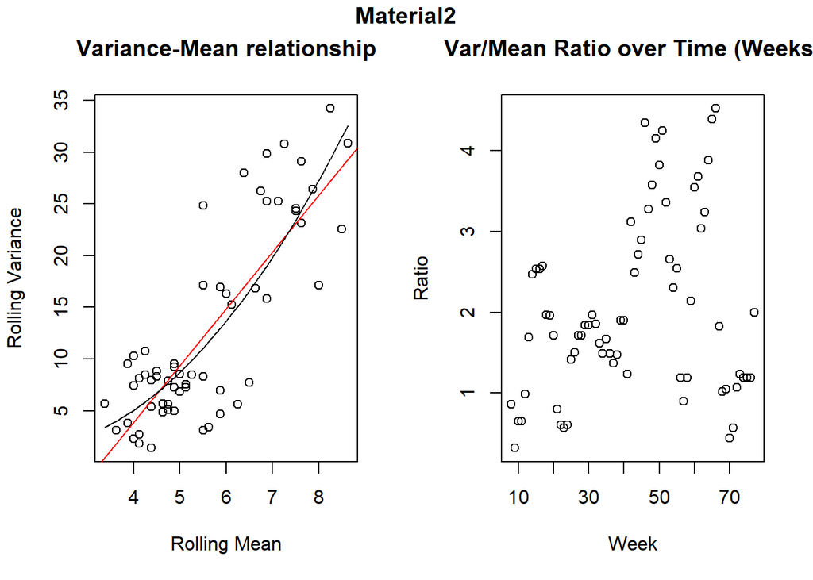

```
## ratio_cv:  0.5458759
```

There is a positive correlation between mean and variance for both materials. In Material1, there is a plausible quadratic fit for the mean-variance relationship, whereas in Material2, the plausibility of the quadratic fit diminishes, although there is a positive correlation visually. The ratio of variance and mean appears to vary across the data for both materials and reaches high values in a large proportion of rolling windows.

In summary, we observed that: 1. Weekly usage distributions are right-tailed. 2. There is positive correlation between restock cycle length and total number of units used per cycle. 3. Usage is overdispersed within rolling windows. 4. Window usage mean is positively correlated with window usage variance.

This indicates that the *Poisson-Gamma mix model* can be used to model the weekly use.

Therefore, *Weekly Use (y) ~ NegBinom(size, prob)*

The posterior parameter update rules become simplified into: size = Prior for Size + sum(Weekly Use) prob = Prior for Duration / (Prior for Duration + Forecast Duration)

# Negative Binomial Fit

We now define 4 functions:

1. **fit_nb_model**: This function computes the posterior parameters for the Poisson–Gamma conjugate model, which leads to a Negative Binomial posterior predictive distribution.

Given weekly usage counts (y) and exposure times (n) and empirical Bayes priors derived from the training window, the function returns: a = a0 + sum(y); b = b0 + sum(n)

These parameters define the posterior distribution of the weekly usage rate and will be used to generate predictive samples.

2. **predict_consumption_nb**: This function uses the posterior parameters from fit_nb_model to simulate posterior predictive outcomes for the total usage over the forecast horizon H_days.

It draws Monte Carlo samples from:

Y_future ~ NegBinom(size = a, prob = b / (b + H_days))

This distribution represents all plausible future usages consistent with past data. The function returns: the median predictive consumption and the raw list of predictive samples (for use in decision-making)

3. **choose_restock_quantity**: This function transforms the predictive distribution into an operational decision.

For a grid of possible inventory stock levels Q, it computes the expected waste fraction:

Expected Waste Fraction(Q) = E[max(Q - Y, 0)] / Q, where Y are the predictive samples.

The function identifies all Q values where: Expected Waste Fraction(Q) <= Waste Threshold

From these, it selects the maximum feasible stock level, i.e., the largest Q that still keeps expected waste below the threshold.

This separates forecasting (uncertainty modeling) from decision-making (choosing stock under business constraints).

4. **cross_validate_nb**: This function performs rolling cross-validation across the time series:

At each time point, use a fixed training window. i. Fit the Bayesian model. ii. Generate the predictive distribution. iii. Apply the decision rule to select optimal stock. iv. Compare predicted vs. actual usage over the forecast horizon. v. Store posteriors, predicted, actual, residuals.

This produces a full time-series evaluation of both predictive performance, decision performance and illustrates how forecasting behaves under real operational variability.

## Functions

```r
fit_nb_model <- function(train_data, level_weights=FALSE) {

  y <- train_data$y
  total <- train_data$stock
  n <- train_data$n

  b0 <- median(n); a0 <- median(y) / b0

  if (level_weights==FALSE) {
    a <- a0 + sum(y); b <- b0 + sum(n)
  } else {

    var_mean_ratio <- var(y) / mean(y)

    if (var_mean_ratio > 3) {
      effective_y_idx <- (y >= quantile(y, 0.10) & (y <= quantile(y, 0.90)))
      effective_y <- y[effective_y_idx]
      effective_n <- n[effective_y_idx]
    } else {

      effective_y <- y
      effective_n <- n
    }

    a <- a0 + sum(effective_y)
    b <- b0 + sum(effective_n)

  }

  return(list(
    a = a,
    b = b
  ))

}
```

```r
predict_consumption_nb <- function(train_data, H_days, Nmc=5000, level_weights=FALSE) {

  predictions <- numeric(Nmc)

  train <- fit_nb_model(train_data=train_data, level_weights=level_weights)
  predictions <- rnbinom(Nmc, size=train$a, prob=train$b / (train$b + H_days))
  expected_demand <- median(predictions)
  prediction_error <- mad(predictions)

  return(list(expected_demand = expected_demand,
              prediction_error = prediction_error,
              predictions = predictions))

}
```

```r
choose_restock_quantity <- function(pred_samples,
                                    waste_frac_max = 0.15,
                                    Q_min = NULL,
                                    Q_max = NULL,
                                    step = 1) {

  if (is.null(Q_min)) Q_min <- quantile(pred_samples, 0.1)
  if (is.null(Q_max)) Q_max <- quantile(pred_samples, 0.95) * 2.0

  Q_grid <- seq(Q_min, Q_max, by = step)

  waste_frac <- sapply(Q_grid, function(Q) {
    expected_waste <- mean(pmax(Q - pred_samples, 0))
    expected_waste / Q
  })

  ok_idx <- which(waste_frac <= waste_frac_max)

  if (length(ok_idx) == 0) {
    return(list(
      Q = median(pred_samples),
      waste_frac = NA,
      Q_grid = Q_grid,
      waste_frac_grid = waste_frac
    ))
  }

  best_Q <- Q_grid[max(ok_idx)]

  list(
    Q = best_Q,
    Q_grid = Q_grid,
    waste_frac_grid = waste_frac
  )
}
```

```r
cross_validate_nb <- function(data, H_days, train_window, step=3, Nmc=1000, level_weights=FALSE, waste_frac_max=0.15) {

  test_window <- floor(H_days/ 7)

  forecast_date <- c(); actual_consumed <- c(); prediction <- c(); residual <- c();
  mean_data <- c(); var_data <- c(); var_mean_ratio <- c(); posteriors <- c()

  for (i in seq(from=1, to=(nrow(data) - train_window - test_window), by=step)) {
    train_data <- data[i:(i + train_window - 1), ]
    test_data <- data[(i + train_window):(i + train_window + test_window - 1), ]

    actual_consumed_i <- sum(test_data$y)

    predict <- predict_consumption_nb(train_data=train_data, H_days=H_days, Nmc=Nmc, level_weights=level_weights)
    decision <- choose_restock_quantity(pred_samples = predict$predictions, waste_frac_max=waste_frac_max)

    predict_i <- decision$Q
    residual_i <- actual_consumed_i - predict_i
    mean_data_i <- mean(train_data$y)
    var_data_i <- var(train_data$y)
    var_mean_ratio_i <- var_data_i / mean_data_i

    plot_df_i <- data.frame(predict=predict$predictions)

    posterior_i <- predict$predictions

    forecast_date <- c(tail(train_data$date, 1), forecast_date)
    actual_consumed <- c(actual_consumed_i, actual_consumed)
    prediction <- c(predict_i, prediction)
    residual <- c(residual_i, residual)
    mean_data <- c(mean_data_i, mean_data)
    var_data <- c(var_data_i, var_data)
    var_mean_ratio <- c(var_mean_ratio_i, var_mean_ratio)
    posteriors <- rbind(posteriors, posterior_i)

  }

  results_df <- data.frame(
    forecast_date = forecast_date,
    actual_consumed = actual_consumed,
    prediction = prediction,
    residual = residual,
    mean_data = mean_data,
    var_data = var_data,
    var_mean_ratio = var_mean_ratio
  )

  results_df <- results_df%>%arrange(forecast_date)

  return(list(results_df=results_df, posteriors=posteriors))

}
```

# Rolling-Origin Evaluation of Forecast

Rolling-origin evaluation is a standard validation technique used in time-series forecasting to obtain a series of forecasts over the validation set. Train window and test window sizes are chosen and multiple forecasts are performed along the validation set by moving through the chosen window lengths. Here, I have used this technique to assess the capacity of this modeling strategy to adapt to and capture varying shifts in the inventory data as we move along the windows.

## Material 1

### Rolling-Origin Evaluation

```r
cross_validate_material1_object <- cross_validate_nb(data=import_data%>%filter(material=='Material1'), H_days=50, train_window=8, step=1, Nmc=1000, level_weights=FALSE, waste_frac_max=0.15)
```

```r
cross_validate_material1 <- cross_validate_material1_object$results_df %>% mutate(row_id = row_number())
```

### Residual Plot

```r
head(cross_validate_material1)
```

```
##   forecast_date actual_consumed prediction residual mean_data  var_data
## 1    2024-06-15             144         86       58    10.875  99.55357
## 2    2024-06-21             119        131      -12    16.125 189.55357
## 3    2024-07-02             112        140      -28    18.500 206.85714
## 4    2024-07-09              95        134      -39    17.750 200.21429
## 5    2024-07-13             103        134      -31    16.750 216.78571
## 6    2024-07-20             111        125      -14    16.750 216.78571
##   var_mean_ratio row_id
## 1       9.154351      1
## 2      11.755260      2
## 3      11.181467      3
## 4      11.279678      4
## 5      12.942431      5
## 6      12.942431      6
```

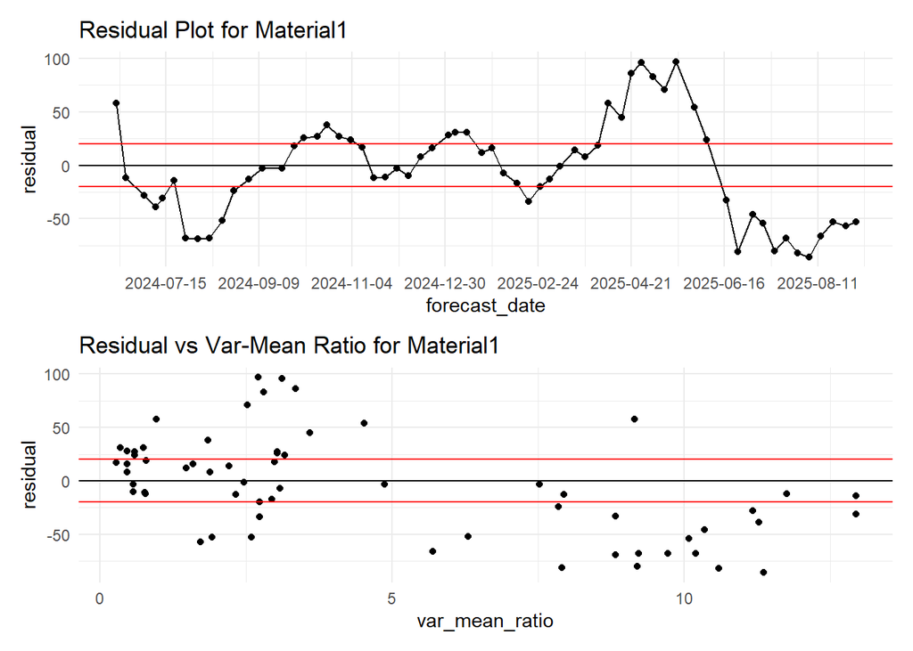

```r
patchwork::wrap_plots(
  ggplot(data=cross_validate_material1, aes(x=forecast_date, y=residual)) +
  geom_line() +
  geom_point() +
  geom_hline(aes(yintercept = 0), color="black") +
  geom_hline(aes(yintercept = 20), color="red") +
  geom_hline(aes(yintercept = -20), color="red") +
  scale_x_date(date_breaks="8 weeks") +
  labs(title="Residual Plot for Material1") +
  theme_minimal(),

ggplot(data=cross_validate_material1, aes(x=var_mean_ratio, y=residual)) +
  geom_point() +
  geom_hline(aes(yintercept = 0), color="black") +
  geom_hline(aes(yintercept = 20), color="red") +
  geom_hline(aes(yintercept = -20), color="red") +
  labs(title="Residual vs Var-Mean Ratio for Material1") +
  theme_minimal(),

  nrow=2,
  ncol=1
)
```

### Posterior Plots for high residual predictions

```r
high_residual_rows_material1 <- sample(x=(cross_validate_material1%>%filter(abs(residual) > 20))$row_id, size=4, replace=FALSE)
```

```r
high_residual_plots_material1 <- lapply(high_residual_rows_material1, function(i) {

  plot_df <- data.frame(posterior=cross_validate_material1_object$posteriors[i, ])
  predicted_value <- cross_validate_material1$prediction[i]
  actual_value <- cross_validate_material1$actual_consumed[i]

  p <- ggplot(data=plot_df) +
    geom_density(aes(x=posterior), fill="grey", alpha=0.4) +
    geom_textvline(aes(xintercept=actual_value), color="blue", label="actual") +
    geom_textvline(aes(xintercept=predicted_value), color="red", label="predicted") +
    theme_minimal()

  return(p)

})
```

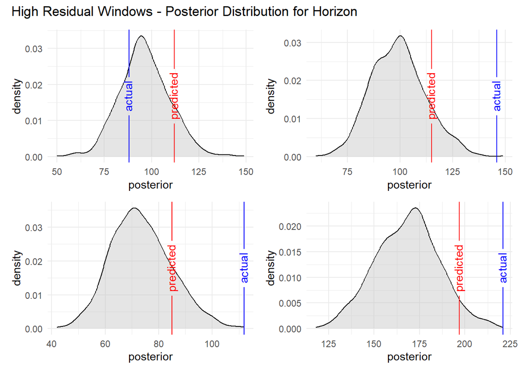

```r
wrap_plots(high_residual_plots_material1) + plot_annotation(title="High Residual Windows - Posterior Distribution for Horizon")
```

Randomly sampled posteriors of high residual predictions show that the actual values typically fall in the tail of the posterior indicating that the Negative Binomial posterior alone could not explain the consumption behavior in those windows.

## Material 2

### Rolling-Origin Evaluation

```r
cross_validate_material2_object <- cross_validate_nb(import_data%>%filter(material=='Material2'), H_days=50, train_window=8, step=1, Nmc=1000, level_weights=TRUE, waste_frac_max=0.15)
```

```r
cross_validate_material2 <- cross_validate_material2_object$results_df %>% mutate(row_id = row_number())
```

### Residual Plots

```r
head(cross_validate_material2)
```

```
##   forecast_date actual_consumed prediction residual mean_data var_data
## 1    2024-06-15              28         27        1     3.625 3.125000
## 2    2024-06-21              28         34       -6     4.375 1.410714
## 3    2024-07-02              31         29        2     4.125 2.696429
## 4    2024-07-09              32         29        3     4.125 2.696429
## 5    2024-07-13              38         29        9     3.875 3.839286
## 6    2024-07-20              40         23       17     3.375 5.696429
##   var_mean_ratio row_id
## 1      0.8620690      1
## 2      0.3224490      2
## 3      0.6536797      3
## 4      0.6536797      4
## 5      0.9907834      5
## 6      1.6878307      6
```

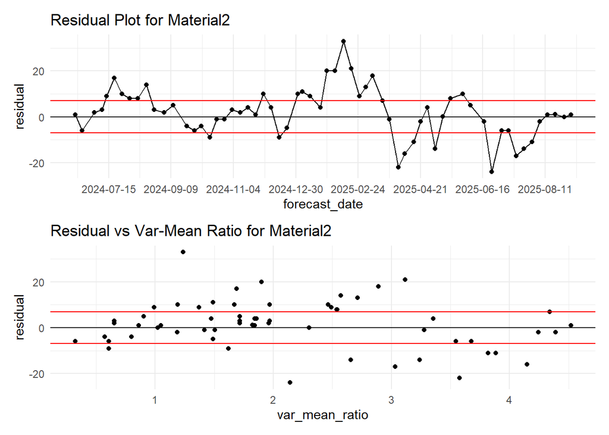

```r
patchwork::wrap_plots(
  ggplot(data=cross_validate_material2, aes(x=forecast_date, y=residual)) +
  geom_line() +
  geom_point() +
  geom_hline(aes(yintercept = 0), color="black") +
  geom_hline(aes(yintercept = 7), color="red") +
  geom_hline(aes(yintercept = -7), color="red") +
  scale_x_date(date_breaks="8 weeks") +
  labs(title="Residual Plot for Material2") +
  theme_minimal(),

ggplot(data=cross_validate_material2, aes(x=var_mean_ratio, y=residual)) +
  geom_point() +
  geom_hline(aes(yintercept = 0), color="black") +
  geom_hline(aes(yintercept = 7), color="red") +
  geom_hline(aes(yintercept = -7), color="red") +
  labs(title="Residual vs Var-Mean Ratio for Material2") +
  theme_minimal(),

  nrow=2,
  ncol=1
)
```

We observe that the residuals highly variable and cross tolerable thresholds. There is also no apparent correlation between residual magnitude and window dispersion (variance-mean ratio).

### Posterior Plots for high residual predictions

```r
high_residual_rows_material2 <- sample(x=(cross_validate_material2%>%filter(abs(residual) > 7))$row_id, size=4, replace=FALSE)
```

```r
high_residual_plots_material2 <- lapply(high_residual_rows_material2, function(i) {

  plot_df <- data.frame(posterior=cross_validate_material2_object$posteriors[i, ])
  predicted_value <- cross_validate_material2$prediction[i]
  actual_value <- cross_validate_material2$actual_consumed[i]

  p <- ggplot(data=plot_df) +
    geom_density(aes(x=posterior), fill="grey", alpha=0.4) +
    geomtextpath::geom_textvline(aes(xintercept=actual_value), color="blue", label="actual") +
    geomtextpath::geom_textvline(aes(xintercept=predicted_value), color="red", label="predicted") +
    theme_minimal()

  return(p)

})
```

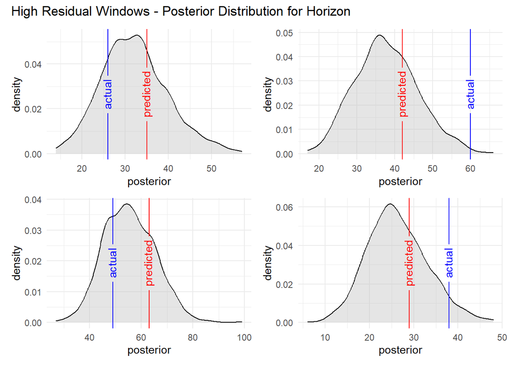

```r
patchwork::wrap_plots(high_residual_plots_material2) + plot_annotation(title="High Residual Windows - Posterior Distribution for Horizon")
```

Randomly sampled posteriors of high residual points show that the actual values can lie within the same quantile of the posterior, however, the tolerable threshold for this Material is too narrow compared to the distribution of residuals. There is also a fair chance for the actual value to lie on the tail of the posterior.

# Lessons Learned

The Bayesian Analysis did not produce stable decision-grade forecasts under these constraints. The analysis shows that the inherent variability in usage is not well captured by a single stochastic process defined by fixed priors and likelihood, even with an overdispersed posterior such as negative binomial. The critical insight I learned is that **some processes are more suited to be managed primarily using human oversight** rather than quantitative analysis. This approach also aligned with the preferred operational method of the team.